# Plotting with GGPlot and Plotly

by Jeon Lee on January 18, 2020

# Basics

ggplot2 is based on the grammar of graphics, the idea that you can build every graph from the same few components: a data set, a set of geoms-visual marks that represent data points, and a coordinate system.

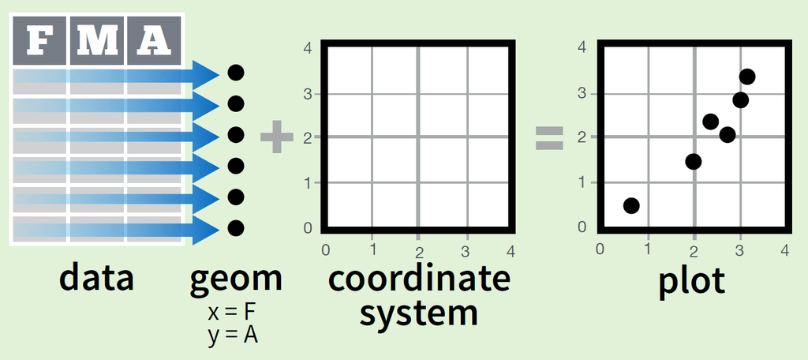

To display data values, map variables in the data set to aesthetic properties of the geom like size, color, and x and y locations.

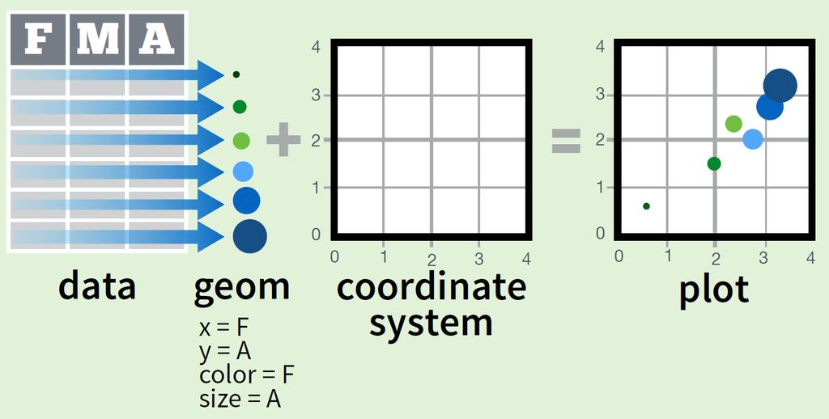

Build a graph with qplot() or ggplot().

qplot() creates a complete plot with given data, geom, and mappings. Supplies many useful defaults.

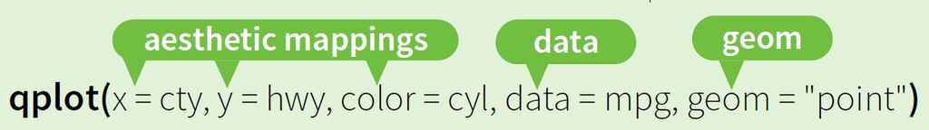

**<Example of qplot()>**

ggplot() begins a plot that you finish by adding layers to. No defaults, but provides more control than qplot().

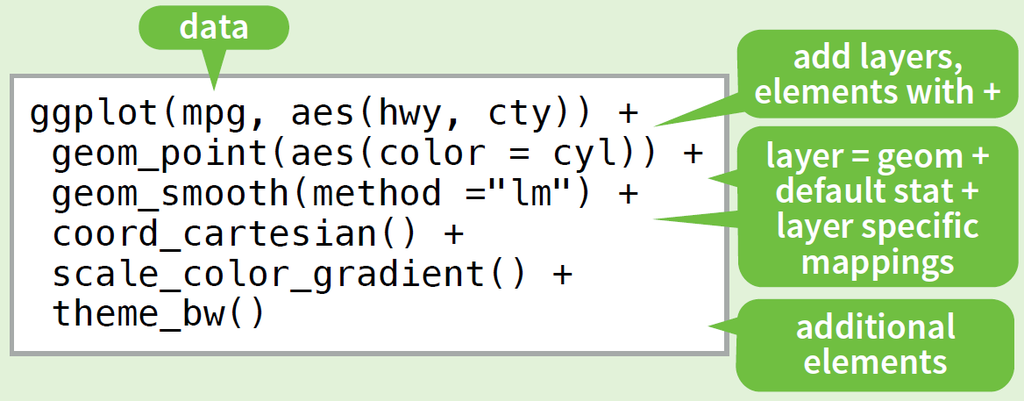

**<Example of ggplot()>**

Add a new layer to a plot with a geom_*() or stat_*() function. Each provides a geom, a set of aesthetic mappings, and a default stat and position adjustment.

# One variable plots

#### 1. Continuous variable

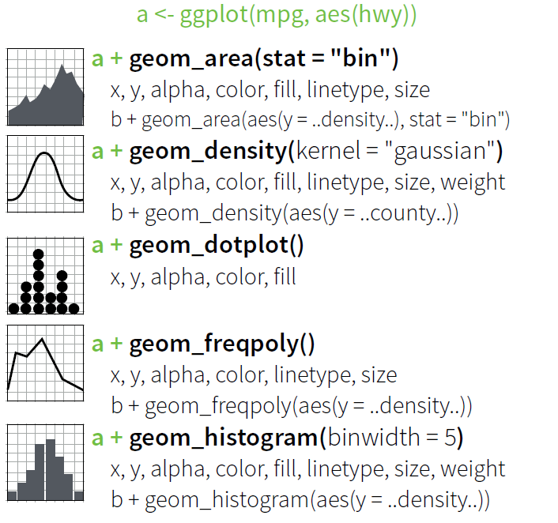

#### 2. Discrete variable

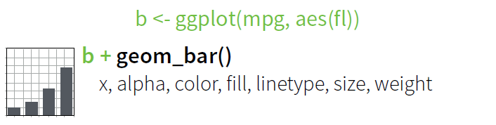

# Two variable plots

#### 1. Continuous X, continuous Y variable

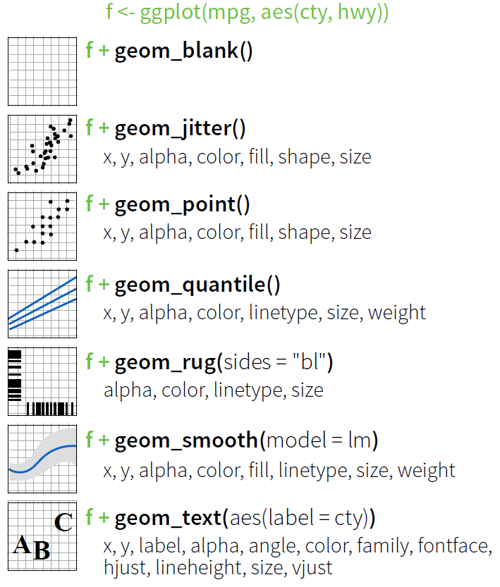

#### 2. Discrete X, continuous Y

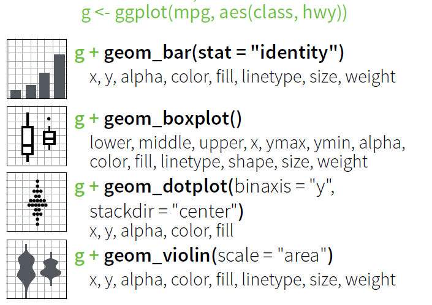

#### 3. Discrete X, discrete Y

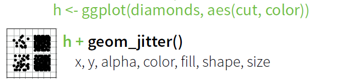

# Hands-on exercise

Please, locate and load a data ‘heightweight.csv’ for the Data Visualization training. Then, change column names a little bit.

```r
library(ggplot2)
library(gridExtra)
my_data <- read.csv("heightweight.csv", header=TRUE)
head(my_data)
```

```
  sex  ageYear ageMonth heightIn weightLb
1   f 11.91667      143     56.3     85.0
2   f 12.91667      155     62.3    105.0
3   f 12.75000      153     63.3    108.0
4   f 13.41667      161     59.0     92.0
5   f 15.91667      191     62.5    112.5
6   f 14.25000      171     62.5    112.0
```

```r
colnames(my_data) <- c("Sex", "Age_Yr", "Age_Mo", "Height", "Weight")
head(my_data)
```

```
  Sex   Age_Yr Age_Mo Height Weight
1   f 11.91667    143   56.3   85.0
2   f 12.91667    155   62.3  105.0
3   f 12.75000    153   63.3  108.0
4   f 13.41667    161   59.0   92.0
5   f 15.91667    191   62.5  112.5
6   f 14.25000    171   62.5  112.0
```

## Scatterplots

#### 1. Basic scatterplot

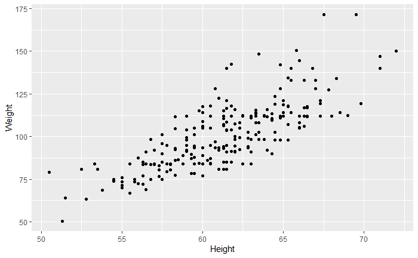

```r
p1 <- ggplot(my_data, aes(x = Height, y = Weight))
# Print plot with default points
p1 + geom_point()
```

#### 2. Change color of points

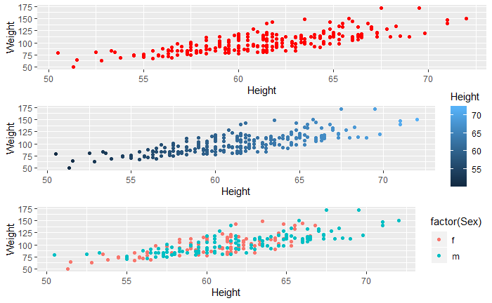

```r
p2 <- p1 + geom_point(color = "red")  #set one color for all points
p3 <- p1 + geom_point(aes(color = Height))  #set color scale by a continuous variable
p4 <- p1 + geom_point(aes(color = factor(Sex)))  #set color scale by a factor variable
grid.arrange(p2, p3, p4, nrow = 3)
```

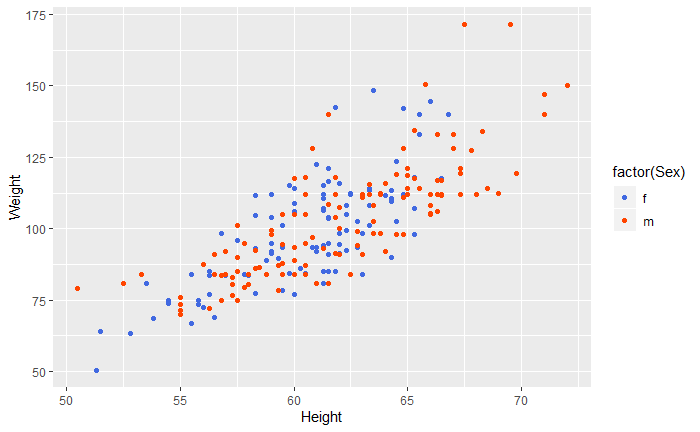

```r
# Change default colors in color scale
p1 + geom_point(aes(color = factor(Sex))) + scale_color_manual(values = c("royalblue","orangered"))
```

for different color names, refer to here

#### 3. Change shape or size of points

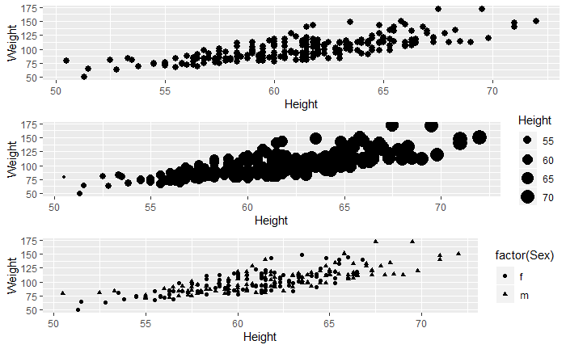

```r
p2 <- p1 + geom_point(size = 2.5)  #increase all points to size 2.5
p3 <- p1 + geom_point(aes(size = Height))  #set point size by continuous variable
p4 <- p1 + geom_point(aes(shape = factor(Sex)))  #set point shape by factor variable
grid.arrange(p2, p3, p4, nrow = 3)
```

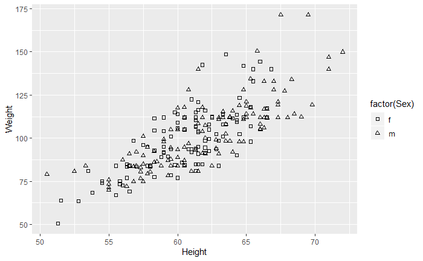

```r
# change the default shapes
p1 + geom_point(aes(shape = factor(Sex))) + scale_shape_manual(values = c(0,2))
```

#### 4. Add lines to scatterplot

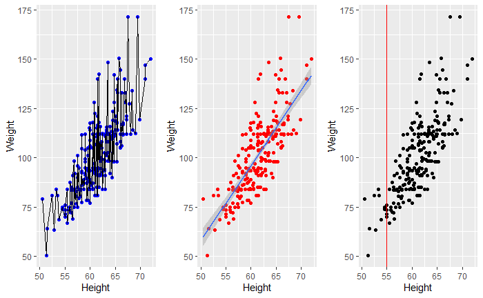

```r
p2 <- p1 + geom_point(color = "blue") + geom_line()  #connect points with line
p3 <- p1 + geom_point(color = "red") + geom_smooth(method = "lm", se = TRUE)  #add regression line
p4 <- p1 + geom_point() + geom_vline(xintercept = 55, color = "red")  #add vertical line
grid.arrange(p2, p3, p4, nrow = 1)
```

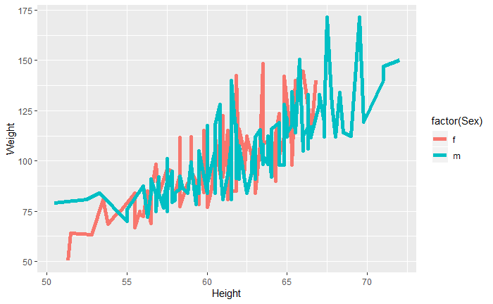

```r
# take out the points, and just create a line plot, and change size and color as before
ggplot(my_data, aes(x = Height, y = Weight)) + geom_line(size = 2, aes(color = factor(Sex)))
```

#### 5. Change axis labels

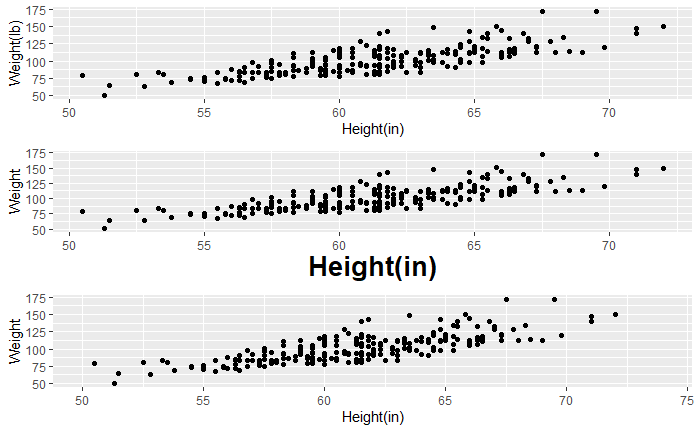

```r
p2 <- ggplot(my_data, aes(x = Height, y = Weight)) + geom_point()
# label all axes at once
p3 <- p2 + labs(x = "Height(in)", y = "Weight(lb)")
# label and change font size
p4 <- p2 + theme(axis.title.x = element_text(face = "bold", size = 20)) + labs(x = "Height(in)")
# adjust axis limits and breaks
p5 <- p2 + scale_x_continuous("Height(in)", limits = c(50, 74), breaks = seq(50,75,5))
grid.arrange(p3, p4, p5, nrow = 3)
```

#### 6. Change legend options

The allowed values for the arguments legend.position are : “left”,“top”, “right”, “bottom”. The argument legend.position can be also a numeric vector c(x,y) whose values range between 0 and 1. In this case, it is possible to position the legend inside the plotting area. x and y are the coordinates of the legend box. For example, c(0,0) corresponds to the “bottom left” and c(1,1) corresponds to the “top right” position.

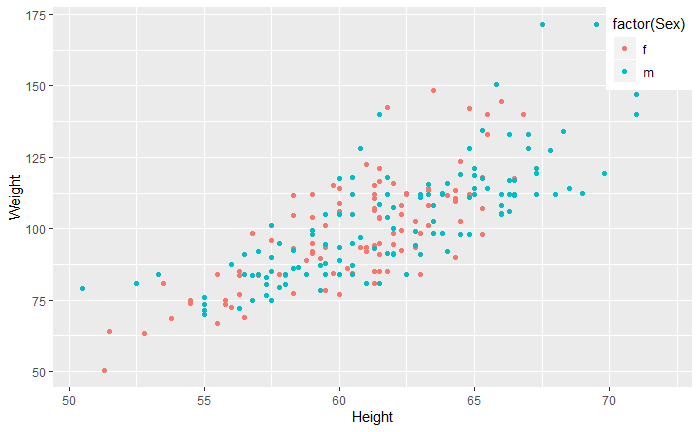

```r
g1<-ggplot(my_data, aes(x = Height, y = Weight)) + geom_point(aes(color=factor(Sex)))
#move legend inside
g2 <- g1 + theme(legend.position=c(1,1),legend.justification=c(1,1))
g2
```

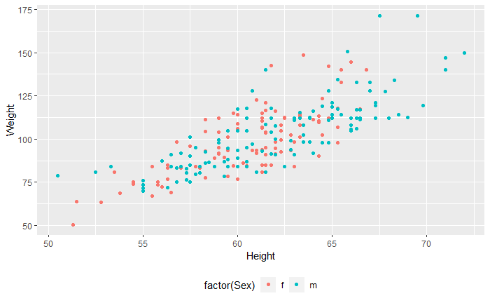

```r
#move legend bottom
g3 <- g1 + theme(legend.position = "bottom")
g3
```

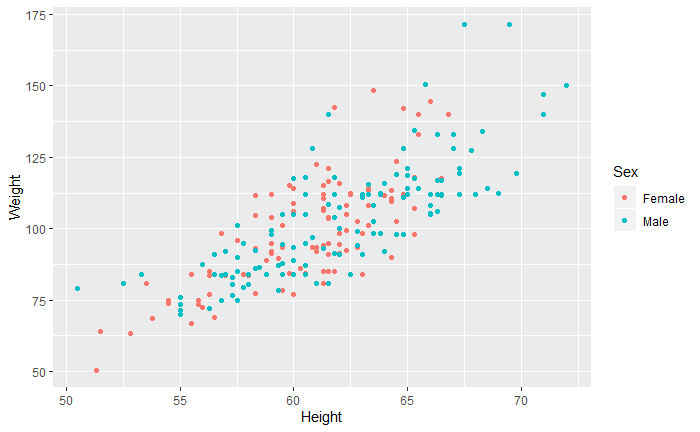

```r
#change labels
g4 <- g1 + scale_color_discrete(name ="Sex", labels=c("Female", "Male"))
g4
```

```r
# grid.arrange(g2, g3, g4, nrow=3)
```

Note that, the argument breaks can be used to control the appearance of the legend.

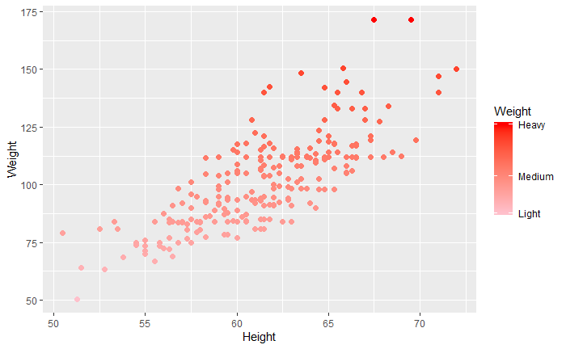

```r
g5<-ggplot(my_data, aes(x = Height, y = Weight)) + geom_point(size=2, aes(color = Weight))
g5 + scale_color_continuous(name="Weight", #name of legend
                            breaks = with(my_data, c(min(Weight), mean(Weight), max(Weight))), #choose breaks of variable
                            labels = c("Light", "Medium", "Heavy"), #label
                            low = "pink",  #color of lowest value
                            high = "red"  #color of highest value
                            )
```

#### 7. Change background color and style

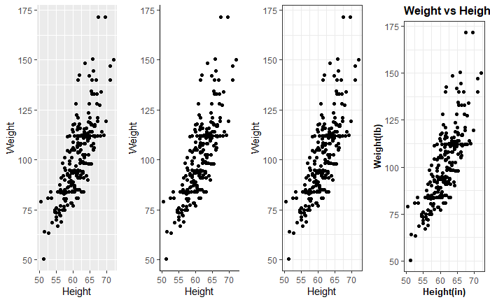

```r
g2 <- ggplot(my_data, aes(x = Height, y = Weight)) + geom_point()
# Completely clear all lines except axis lines and make background white
t1 <- theme(plot.background = element_blank(), panel.grid.major = element_blank(),
            panel.grid.minor = element_blank(), panel.border = element_blank(), panel.background = element_blank(),
            axis.line = element_line(size = 0.4))
# Use theme to change axis label style
t2 <- theme(axis.title.x = element_text(face = "bold", color = "black", size = 10),
            axis.title.y = element_text(face = "bold", color = "black", size = 10),
            plot.title = element_text(face = "bold", color = "black", size = 12))
g3 <- g2 + t1
g4 <- g2 + theme_bw()
g5 <- g2 + theme_bw() + t2 + labs(x = "Height(in)", y = "Weight(lb)", title = "Weight vs Height")
grid.arrange(g2, g3, g4, g5, nrow = 1)
```

#### 8. a nice graph using a combination of options

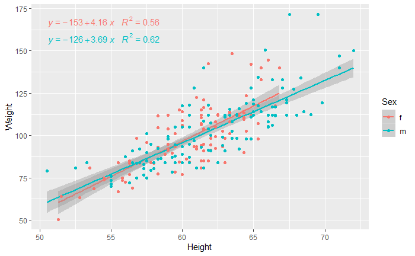

```r
library(ggpmisc)
my.formula <- y ~ x
g2 <- ggplot(my_data, aes(x = Height, y = Weight, colour=Sex)) +
  geom_smooth(aes(color = factor(Sex)), method = "lm",se = TRUE, formula = my.formula) +
  stat_poly_eq(formula = my.formula,
               aes(label = paste(..eq.label.., ..rr.label.., sep = "~~~")),
               parse = TRUE) +
  geom_point(aes(color=Sex))
g2
```

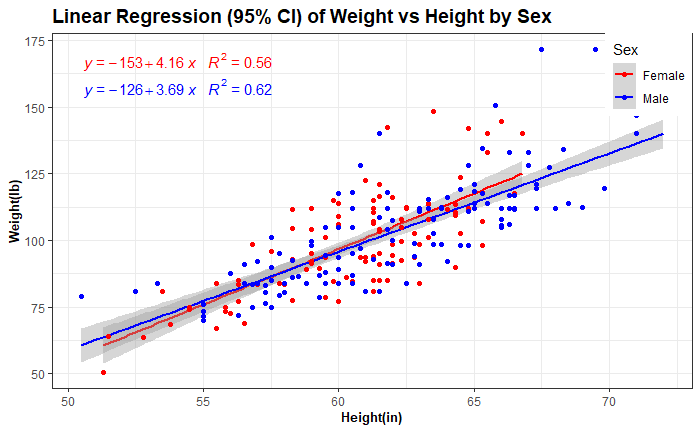

```r
g2 <- g2 +
  scale_color_manual(name = "Sex", labels = c("Female","Male"), values = c("red", "blue")) +
  scale_shape_manual(name = "Sex", labels = c("Female","Male"), values = c(0, 2)) +
  theme_bw() +
  theme(axis.title.x = element_text(face = "bold", color = "black", size = 10),
        axis.title.y = element_text(face = "bold", color = "black", size = 10),
        plot.title = element_text(face = "bold", color = "black", size = 14),
        legend.position = c(1, 1), legend.justification = c(1, 1)) +
  labs(x = "Height(in)",y = "Weight(lb)", title = "Linear Regression (95% CI) of Weight vs Height by Sex")
g2
```

## Barplots

#### 1. Basic barplot

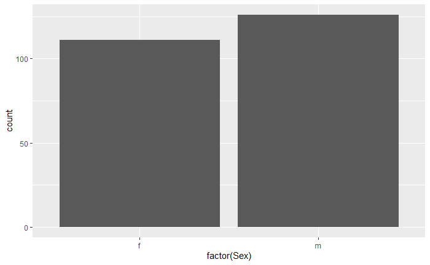

```r
ggplot(my_data, aes(x = factor(Sex))) + geom_bar(stat = "count")
```

#### 2. Horizontal bars, colors, width of bars

**stat_summary** allows for tremendous flexibilty in the specification of summary functions. The summary function can either operate on a data frame (with argument name **fun.data**) or on a vector (**fun.y**, **fun.ymax**, **fun.ymin**).

```r
# 1. horizontal bars
p1 <- ggplot(my_data, aes(x = factor(Sex), y = Weight)) +
  stat_summary(fun.y = mean,geom = "bar") + coord_flip()
# 2. change colors of bars
p2 <- ggplot(my_data, aes(x = factor(Sex), y = Weight, fill = factor(Sex))) +
  stat_summary(fun.y = mean,geom = "bar") + scale_fill_manual(values = c("orangered", "royalblue"))
# 3. change width of bars
p3 <- ggplot(my_data, aes(x = factor(Sex), y = Weight)) +
  stat_summary(fun.y = mean,geom = "bar", aes(width = 0.5))
```

```
Ignoring unknown aesthetics: width
```

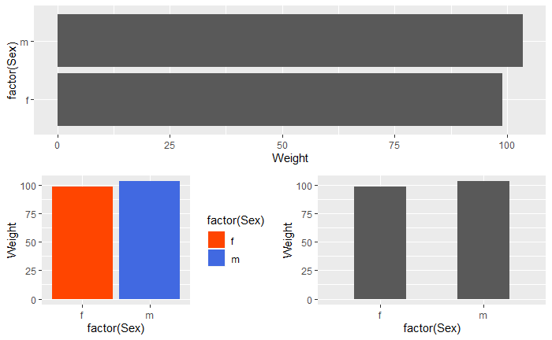

```r
grid.arrange(p1,                             # First row with one plot spaning over 2 columns
             arrangeGrob(p2, p3, ncol = 2),  # Second row with 2 plots in 2 different columns
             nrow = 2)                       # Number of rows
```

#### 3. Split and color by another variable

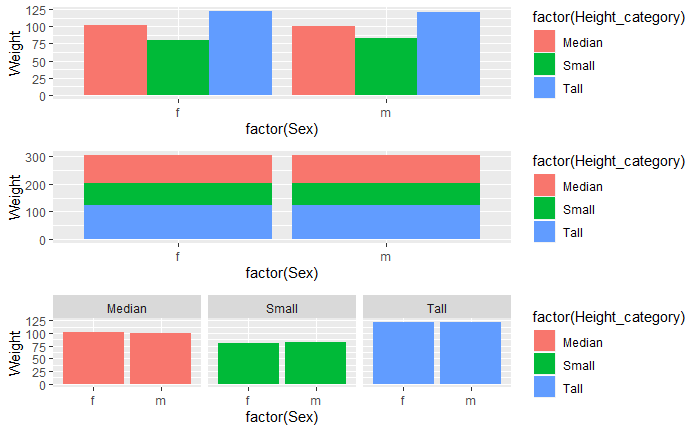

```r
# Categorize height values into 3 groups: 'Small', 'Median', and 'Tall'
my_data$Height_category <- c('Median')
my_data$Height_category[my_data$Height > quantile(my_data$Height, 0.75)] <- c('Tall')
my_data$Height_category[my_data$Height < quantile(my_data$Height, 0.25)] <- c('Small')
# 1. next to each other
p1 <- ggplot(my_data, aes(x = factor(Sex), y = Weight, fill = factor(Height_category)), color = factor(Height_category)) +
stat_summary(fun.y = mean, position = position_dodge(), geom = "bar")
# 2. stacked
p2 <- ggplot(my_data, aes(x = factor(Sex), y = Weight, fill = factor(Height_category)), color = factor(Height_category)) +
stat_summary(fun.y = mean, position = "stack", geom = "bar")
# 3. with facets
p3 <- ggplot(my_data, aes(x = factor(Sex), y = Weight, fill = factor(Height_category)), color = factor(Height_category)) +
stat_summary(fun.y = mean, geom = "bar") + facet_wrap(~Height_category)
grid.arrange(p1, p2, p3, nrow = 3)
```

#### 4. Add text to the bars, label axes, and label legend

```r
ag.my_data <- aggregate(my_data$Weight, by = list(my_data$Sex, my_data$Height_category), FUN = mean)
colnames(ag.my_data) <- c("Sex", "Height_category", "mean_Weight")
ag.my_data
```

```
  Sex Height_category mean_Weight
1   f          Median   102.24638
2   m          Median   100.29808
3   f           Small    80.36207
4   m           Small    82.76667
5   f            Tall   122.30769
6   m            Tall   121.27273
```

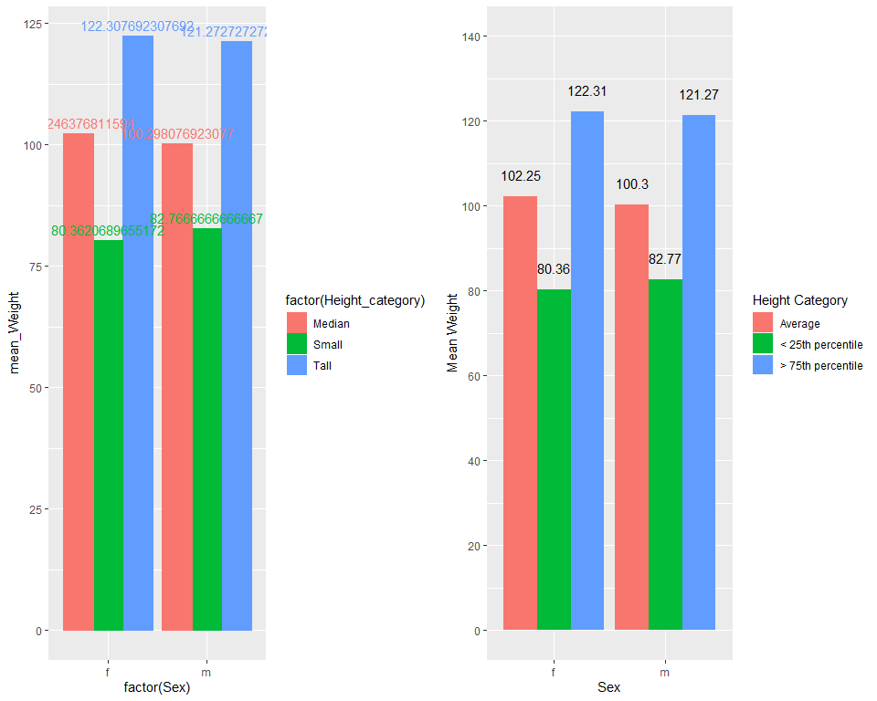

```r
# 1. basic
g1 <- ggplot(ag.my_data, aes(x = factor(Sex), y = mean_Weight, fill = factor(Height_category),
                               color = factor(Height_category))) +
  geom_bar(stat = "identity", position = position_dodge()) +
  geom_text(aes(y = mean_Weight, label = mean_Weight),
            position = position_dodge(width = 0.9), vjust = -0.5)
# 2. fixing the yaxis problem, changing the color of text, legend labels, and rounding to 2 decimals
g2 <- ggplot(ag.my_data, aes(x = factor(Sex), y = mean_Weight, fill = factor(Height_category))) +
  geom_bar(stat = "identity", position = position_dodge()) +
  geom_text(aes(y = mean_Weight, label = round(mean_Weight, 2)),
            position = position_dodge(width = 0.9), vjust = -1.5, color = "black") +
  scale_x_discrete("Sex") +
  scale_y_continuous("Mean Weight", limits = c(0,140), breaks = seq(0,140,20)) +
  scale_fill_discrete(name = "Height Category", labels = c("Average", "< 25th percentile", "> 75th percentile"))
grid.arrange(g1, g2, nrow = 1)
```

#### 5. Add error bars

```r
summary.my_data <- data.frame(Sex = levels(as.factor(my_data$Sex)),
                              mean_Wt = tapply(my_data$Weight,my_data$Sex, mean),
                              sd_Wt = tapply(my_data$Weight, my_data$Sex, sd))
summary.my_data
```

```
  Sex   mean_Wt    sd_Wt
f   f  98.87838 18.61600
m   m 103.44841 19.96806
```

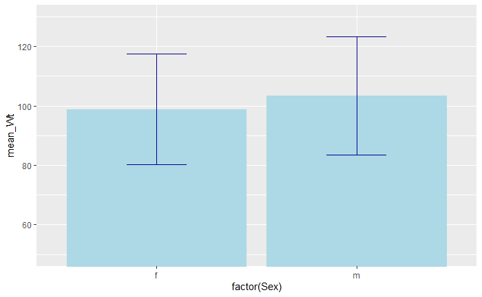

```r
ggplot(summary.my_data, aes(x = factor(Sex), y = mean_Wt)) +
  geom_bar(stat = "identity", position = "dodge", fill = "lightblue") +
  coord_cartesian(ylim=c(50,130)) +
  geom_errorbar(aes(ymin = mean_Wt - sd_Wt, ymax = mean_Wt + sd_Wt), width = 0.3, color = "darkblue")
```

#### 6. Add best fit line

```r
# summarize data
summary.my_data2 <- data.frame(ht = levels(as.factor(my_data$Height)),
                               mean_wt = tapply(my_data$Weight, my_data$Height, mean))
levels(as.factor(my_data$Height))
```

```
 [1] "50.5" "51.3" "51.5" "52.5" "52.8" "53.3" "53.5" "53.8" "54.5" "55"   "55.5" "55.8" "56"   "56.3" "56.5" "56.8"
[17] "57"   "57.3" "57.5" "57.8" "58"   "58.3" "58.5" "58.8" "59"   "59.3" "59.5" "59.8" "60"   "60.3" "60.5" "60.8"
[33] "61"   "61.3" "61.5" "61.8" "62"   "62.3" "62.5" "62.8" "63"   "63.3" "63.5" "63.8" "64"   "64.3" "64.5" "64.8"
[49] "65"   "65.3" "65.5" "65.8" "66"   "66.3" "66.5" "66.8" "67"   "67.3" "67.5" "67.8" "68"   "68.3" "68.5" "69"
[65] "69.5" "69.8" "71"   "72"
```

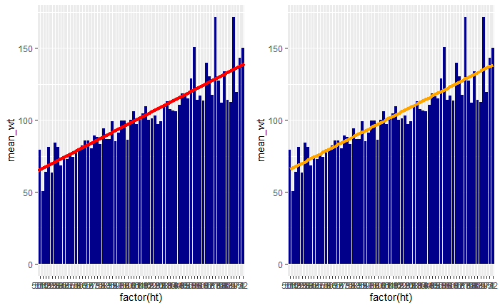

```r
# run a model
l <- summary(lm(mean_wt ~ as.numeric(ht), data = summary.my_data2))
# manually entering the intercept and slope
f1 <- ggplot(summary.my_data2, aes(x = factor(ht), y = mean_wt)) +
  geom_bar(stat = "identity", fill = "darkblue") +
  geom_abline(aes(intercept = l$coef[1, 1], slope = l$coef[2, 1]), color = "red", size = 1.5)
# using stat_smooth to fit the line for you
f2 <- ggplot(summary.my_data2, aes(x = factor(ht), y = mean_wt)) +
  geom_bar(stat = "identity", fill = "darkblue") +
  stat_smooth(aes(group = 1), method = "lm", se = FALSE, color = "orange", size = 1.5)
grid.arrange(f1, f2, nrow = 1)
```

## Histograms

```r
# generate two random variables, X and Y, and then data pairs (x, y)
set.seed(999)
xvar <- c(rnorm(1500, mean = -1), rnorm(1500, mean = 1.5))
yvar <- c(rnorm(1500, mean = 1), rnorm(1500, mean = 1.5))
zvar <- as.factor(c(rep(1, 1500), rep(2, 1500)))
xy <- data.frame(xvar, yvar, zvar)
head(xy)
```

```
        xvar       yvar zvar
1 -1.2817402  1.5531686    1
2 -2.3125596  0.5149727    1
3 -0.2048160  0.4607868    1
4 -0.7299295  0.5450151    1
5 -1.2773064 -0.5317186    1
6 -1.5660237 -0.6303615    1
```

```r
tail(xy)
```

```
           xvar      yvar zvar
2995  1.1380290 1.5815419    2
2996  1.3531130 1.3259383    2
2997  2.5896593 0.3654012    2
2998 -0.3946385 2.3967368    2
2999  0.7213553 1.1091168    2
3000  1.3084922 2.1637244    2
```

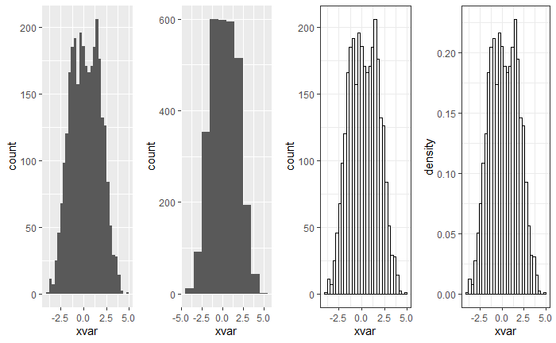

```r
# counts on y-axis
g1 <- ggplot(xy, aes(xvar)) + geom_histogram()  #horribly ugly default
g2 <- ggplot(xy, aes(xvar)) + geom_histogram(binwidth = 1)  #change binwidth
g3 <- ggplot(xy, aes(xvar)) + geom_histogram(fill = NA, color = "black") + theme_bw()  #nicer looking
# density on y-axis
g4 <- ggplot(xy, aes(x = xvar)) +
  geom_histogram(aes(y = ..density..), color = "black", fill = NA) + theme_bw()
grid.arrange(g1, g2, g3, g4, nrow = 1)
```

## Density plots

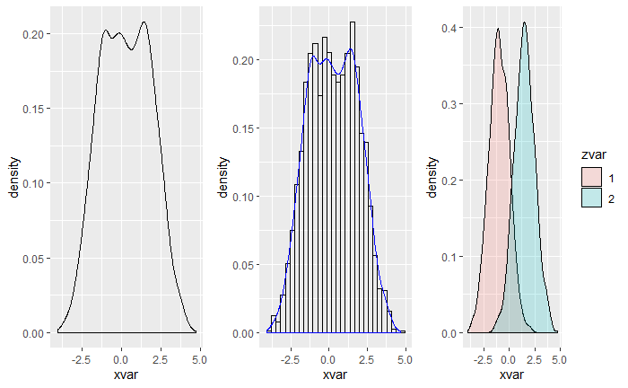

```r
# basic density
p1 <- ggplot(xy, aes(xvar)) + geom_density()
# histogram with density line overlaid
p2 <- ggplot(xy, aes(x = xvar)) +
  geom_histogram(aes(y = ..density..), color = "black", fill = NA) + geom_density(color = "blue")
# split and color by third variable, alpha fades the color a bit
p3 <- ggplot(xy, aes(xvar, fill = zvar)) + geom_density(alpha = 0.2)
grid.arrange(p1, p2, p3, nrow = 1)
```

## Boxplots

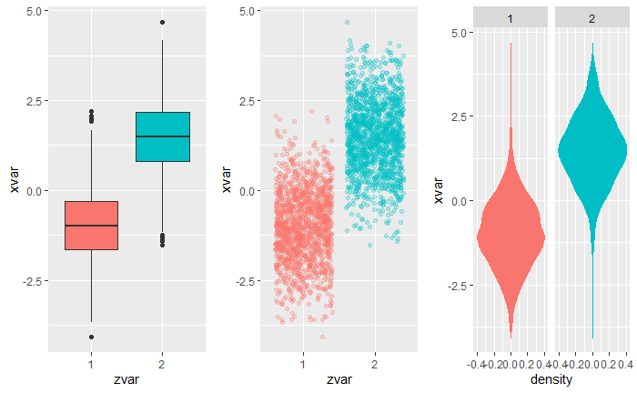

```r
# boxplot
b1 <- ggplot(xy, aes(zvar, xvar)) + geom_boxplot(aes(fill = zvar)) + theme(legend.position = "none")
# jitter plot
b2 <- ggplot(xy, aes(zvar, xvar)) + geom_jitter(alpha = I(1/4), aes(color = zvar)) + theme(legend.position = "none")
# violin plot
b3 <- ggplot(xy, aes(x = xvar)) +
  stat_density(aes(ymax = ..density.., ymin = -..density.., fill = zvar, color = zvar),
               geom = "ribbon", position = "identity") +
  facet_grid(. ~ zvar) + coord_flip() + theme(legend.position = "none")
grid.arrange(b1, b2, b3, nrow = 1)
```

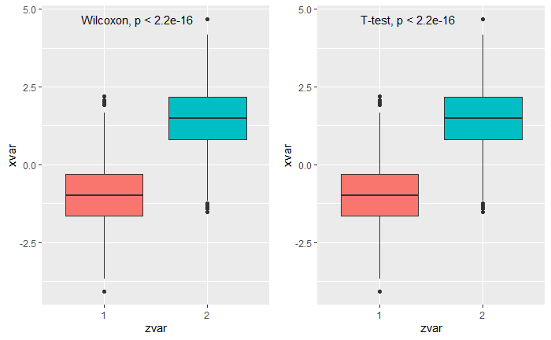

```r
# Add p-value
library(ggpubr)
b4 <- b1 + stat_compare_means()
# Change test method
b5 <- b1 + stat_compare_means(method = "t.test")
grid.arrange(b4, b5, nrow = 1)
```

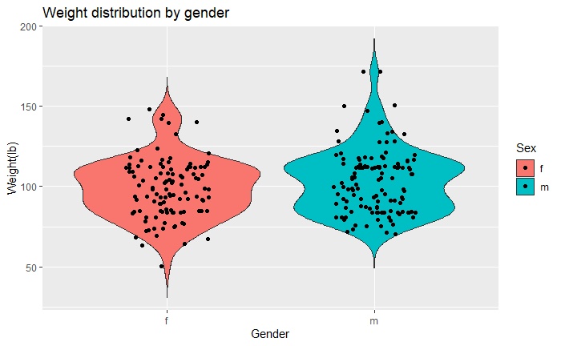

```r
p<-ggplot(my_data, aes(x = Sex, y = Weight, fill=Sex)) +
  geom_violin(trim=FALSE) +
  geom_jitter(shape=16, position=position_jitter(0.2)) +
  labs(title="Weight distribution by gender",x="Gender", y = "Weight(lb)")
p
```

## Putting multiple plots together

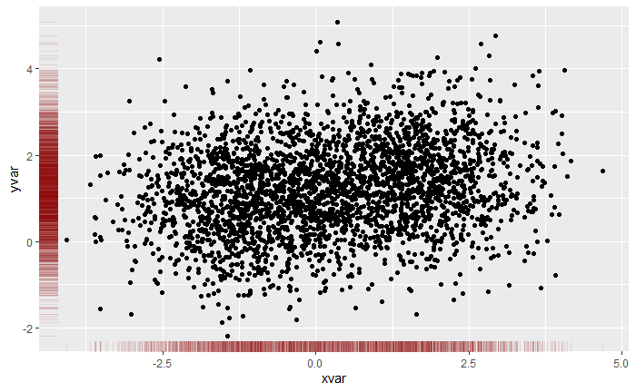

```r
# rug plot
ggplot(xy, aes(xvar, yvar)) + geom_point() + geom_rug(col = "darkred", alpha = 0.1)
```

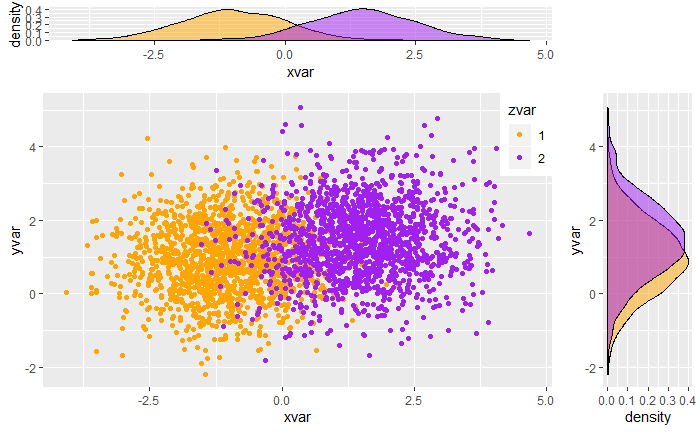

```r
# placeholder plot - prints nothing at all
empty <- ggplot() + geom_point(aes(1, 1), colour = "white") +
  theme(plot.background = element_blank(),panel.grid.major = element_blank(), panel.grid.minor = element_blank(),
        panel.border = element_blank(), panel.background = element_blank(), axis.title.x = element_blank(),
        axis.title.y = element_blank(), axis.text.x = element_blank(), axis.text.y = element_blank(),
        axis.ticks = element_blank())
# scatterplot of x and y variables
scatter <- ggplot(xy, aes(xvar, yvar)) +
  geom_point(aes(color = zvar)) + scale_color_manual(values = c("orange","purple")) +
  theme(legend.position = c(1, 1), legend.justification = c(1,1))
# marginal density of x - plot on top
plot_top <- ggplot(xy, aes(xvar, fill = zvar)) + geom_density(alpha = 0.5) +
scale_fill_manual(values = c("orange", "purple")) + theme(legend.position = "none")
# marginal density of y - plot on the right
plot_right <- ggplot(xy, aes(yvar, fill = zvar)) + geom_density(alpha = 0.5) +
  coord_flip() + scale_fill_manual(values = c("orange", "purple")) + theme(legend.position = "none")
# arrange the plots together, with appropriate height and width for each row and column
grid.arrange(plot_top, empty, scatter, plot_right, ncol = 2, nrow = 2, widths = c(4,1), heights = c(1, 4))
```

## Ploty plot

Plotly is an R package for creating interactive web-based graphs via the open source JavaScript graphing library plotly.js. As of version 2.0 (November 17, 2015), Plotly graphs are rendered locally through the htmlwidgets framework.

#### 1. Scatter plot

```r
#install.packages("plotly")
library(plotly)
#View(iris)
#Basic Scatter Plot
p <- plot_ly(data = iris, x = ~Sepal.Length, y = ~Petal.Length)
p
#Qualitative Colorscales
p <- plot_ly(data = iris, x = ~Sepal.Length, y = ~Petal.Length, color = ~Species)
p
htmlwidgets::saveWidget(as.widget(p), "Ploty_ScatterPlot.html")
```

[output not shown]

#### 2. Boxplot

```r
#View(my_data)
p <- plot_ly(my_data, x = ~Height, color = ~Height_category, type = "box")
p
htmlwidgets::saveWidget(as.widget(p), "Ploty_BoxPlot.html")
```

```
'as.widget' is deprecated.
Use 'as_widget' instead.
See help("Deprecated")
```

#### 3. Volcano plot

```r
#library(DESeq2)
#===Define my_VolcanoPlot
my_VolcanoPlot <- function(tb_sigGenes, tb_DESeq_res) {
  a <- list()
  for (i in seq_len(nrow(tb_sigGenes))) {
    m <- tb_sigGenes[i, ]
    a[[i]] <- list(
      x = m[["log2FC"]],
      y = -log10(m[["padj"]]),
      text = m[["Genes"]],
      xref = "x",
      yref = "y",
      showarrow = TRUE,
      arrowhead = 0.5,
      ax = 20,
      ay = -40
    )
  }

  p <- plot_ly(data = tb_DESeq_res, x = ~log2FC, y = ~-log10(padj), type="scatter", text = ~Genes, mode = "markers", color = ~Category) %>%
    layout(title ="Volcano Plot") %>%
    layout(annotations = a)

  return(p)
}
m <- list(
  l = 50,
  r = 50,
  b = 100,
  t = 100,
  pad = 4
)
#=====================#
# load a data file containing a count table and DESeq analysis results
myResult <- read.csv("m5B_vs_WT_rnaseq.csv", header=TRUE, row.names = 1)
myResult <- myResult[1:1000,]
sig_genes <- myResult[which(myResult$Category!="NotSignificant"),]
p <- my_VolcanoPlot(sig_genes, myResult)
p
```

```
Ignoring 645 observations
```

```r
htmlwidgets::saveWidget(as.widget(p), "Ploty_VolcanoPlot.html")
```

```
'as.widget' is deprecated.
Use 'as_widget' instead.
See help("Deprecated")Ignoring 645 observations
```

## Extra-excercise: heatmap

pheatmap() can plot a heatmap embedding hierarchical clustering results along each of the column and row.

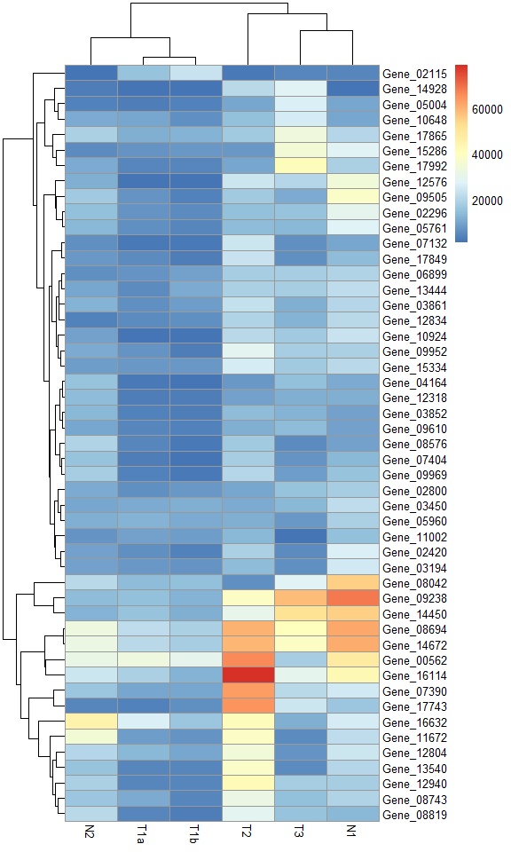

```r
#install.packages(pheatmap)
library(pheatmap)
#if (!requireNamespace("BiocManager", quietly = TRUE))
#     install.packages("BiocManager")
# BiocManager::install("DESeq")
library("DESeq")

# load data and subset
example_file <- system.file ("extra/TagSeqExample.tab", package="DESeq")
data <- read.delim(example_file, header=T, row.names="gene")
data_subset <- as.matrix(data[rowSums(data)>50000,])

# create heatmap using pheatmap
pheatmap(data_subset)
```

We can add column and row annotations to a heatmap and below I’ll add some random annotations.

```r
# column annotation preparation
my_sample_col <- data.frame(sample = rep(c("tumour", "normal"), c(4,2)))
row.names(my_sample_col) <- colnames(data_subset)

my_sample_col
```

```
    sample
T1a tumour
T1b tumour
T2  tumour
T3  tumour
N1  normal
N2  normal
```

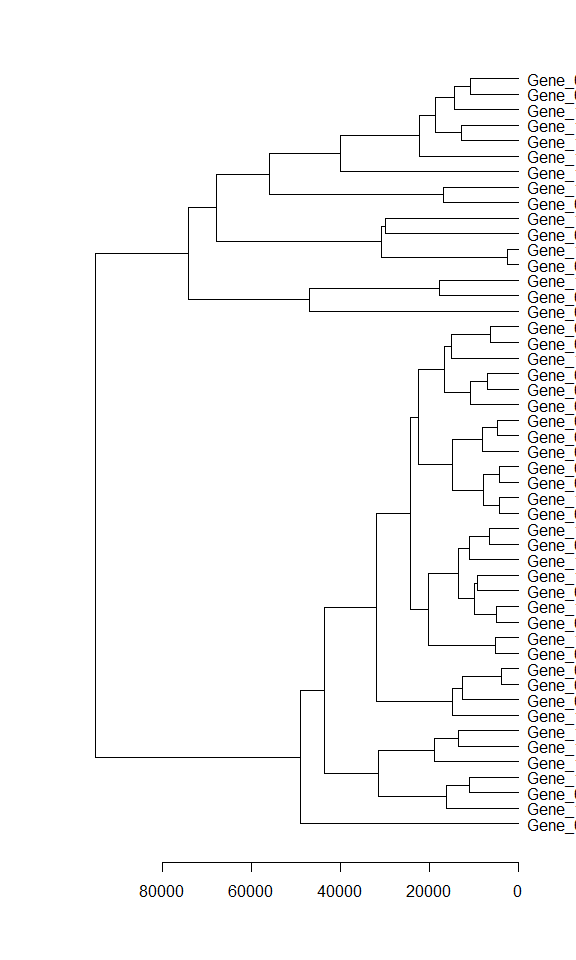

```r
# row annotation preparation
my_hclust_gene <- hclust(dist(data_subset), method = "complete")

#install.packages("dendextend")
library(dendextend)

as.dendrogram(my_hclust_gene) %>%
  plot(horiz = TRUE)
```

```r
my_gene_col <- cutree(tree = as.dendrogram(my_hclust_gene), k = 2)
head(my_gene_col)
```

```
Gene_00562 Gene_02115 Gene_02296 Gene_02420 Gene_02800 Gene_03194
         1          2          2          2          2          2
```

```r
my_gene_col <- data.frame(cluster = ifelse(test = my_gene_col == 1, yes = "cluster 1", no = "cluster 2"))
head(my_gene_col)
```

```
             cluster
Gene_00562 cluster 1
Gene_02115 cluster 2
Gene_02296 cluster 2
Gene_02420 cluster 2
Gene_02800 cluster 2
Gene_03194 cluster 2
```

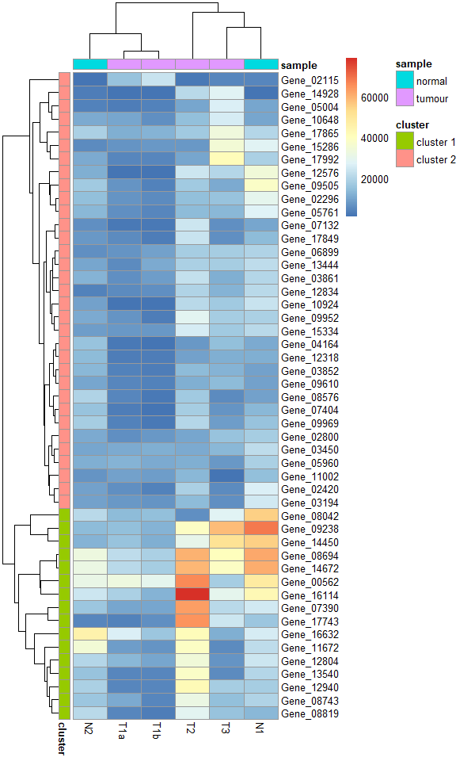

```r
pheatmap(data_subset, annotation_row = my_gene_col, annotation_col = my_sample_col)
```

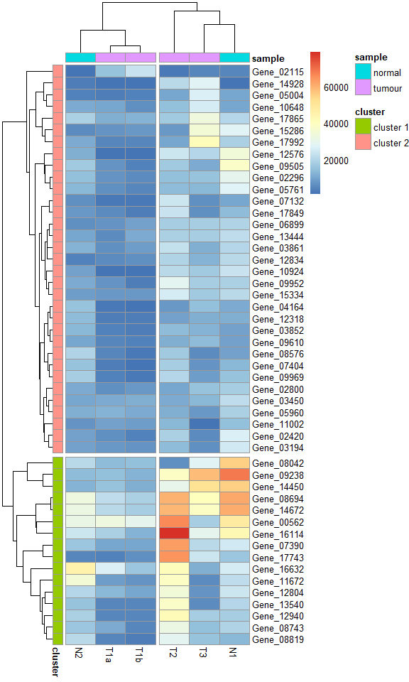

```r
pheatmap(data_subset, annotation_row = my_gene_col, annotation_col = my_sample_col, cutree_rows = 2, cutree_cols = 2)
```

## Extra-excercise: correlation plot

corrplot() can visualize a correlation matrix. Seven different visualization methods can be used : “circle”, “square”, “ellipse”, “number”, “shade”, “color”, “pie”.

```r
#install.packages("corrplot")
library(corrplot)
# Data for correlation analysis: mtcars
head(mtcars)
```

```
                   mpg cyl disp  hp drat    wt  qsec vs am gear carb
Mazda RX4         21.0   6  160 110 3.90 2.620 16.46  0  1    4    4
Mazda RX4 Wag     21.0   6  160 110 3.90 2.875 17.02  0  1    4    4
Datsun 710        22.8   4  108  93 3.85 2.320 18.61  1  1    4    1
Hornet 4 Drive    21.4   6  258 110 3.08 3.215 19.44  1  0    3    1
Hornet Sportabout 18.7   8  360 175 3.15 3.440 17.02  0  0    3    2
Valiant           18.1   6  225 105 2.76 3.460 20.22  1  0    3    1
```

```r
# Computing correlation matrix
M <- cor(mtcars)
head(round(M,2))
```

```
       mpg   cyl  disp    hp  drat    wt  qsec    vs    am  gear  carb
mpg   1.00 -0.85 -0.85 -0.78  0.68 -0.87  0.42  0.66  0.60  0.48 -0.55
cyl  -0.85  1.00  0.90  0.83 -0.70  0.78 -0.59 -0.81 -0.52 -0.49  0.53
disp -0.85  0.90  1.00  0.79 -0.71  0.89 -0.43 -0.71 -0.59 -0.56  0.39
hp   -0.78  0.83  0.79  1.00 -0.45  0.66 -0.71 -0.72 -0.24 -0.13  0.75
drat  0.68 -0.70 -0.71 -0.45  1.00 -0.71  0.09  0.44  0.71  0.70 -0.09
wt   -0.87  0.78  0.89  0.66 -0.71  1.00 -0.17 -0.55 -0.69 -0.58  0.43
```

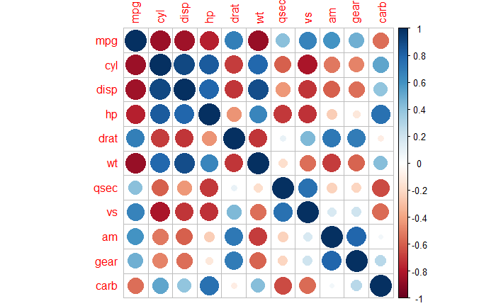

```r
# Visualizing the correlation matrix: corrplot()
corrplot(M, method="circle")
```

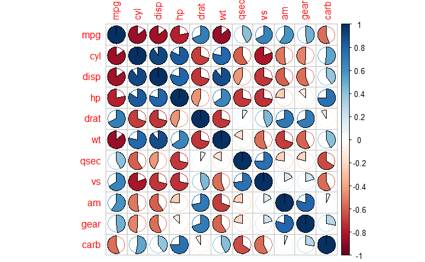

```r
corrplot(M, method="pie")
```

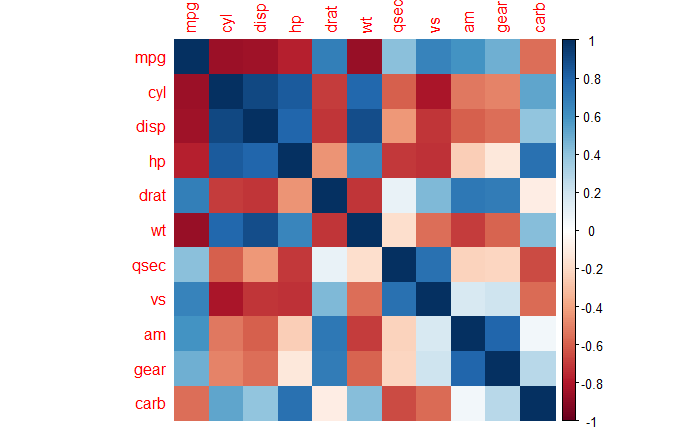

```r
corrplot(M, method="color")
```

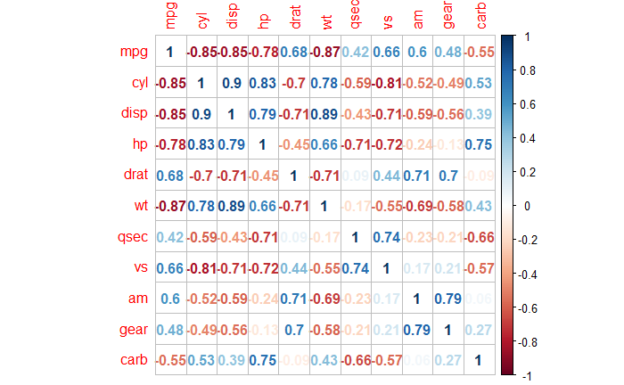

```r
corrplot(M, method="number")
```

$~$

#### [Thanks! It’s the end of ‘Plotting with GGPlot and Plotly’]